# EDA FINAL PROJECT

E. Kren

06/2020

## Stations

First, let’s run through the general questions that interest us:

**1. Where are the stations located?**

All stations located in Europe. Here we can see a list of all countries:

```
##  [1] "FR" "CZ" "SK" "SE" "DE" "IS" "NL" "HU" "PL" "RS" "GB" "NO" "RO" "FI" "DK"
## [16] "CH" "RU" "LT" "UA"
```

**2. How many stations/rivers exist per country?**

Using R tools we get a nice plot showing us stations and rivers per country:

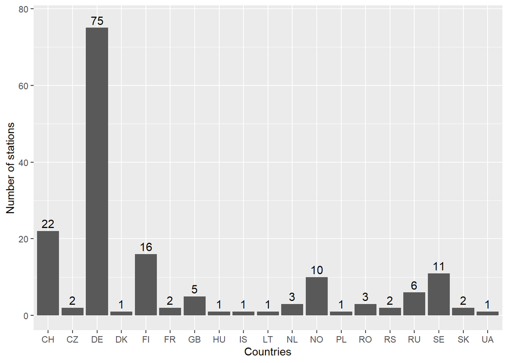

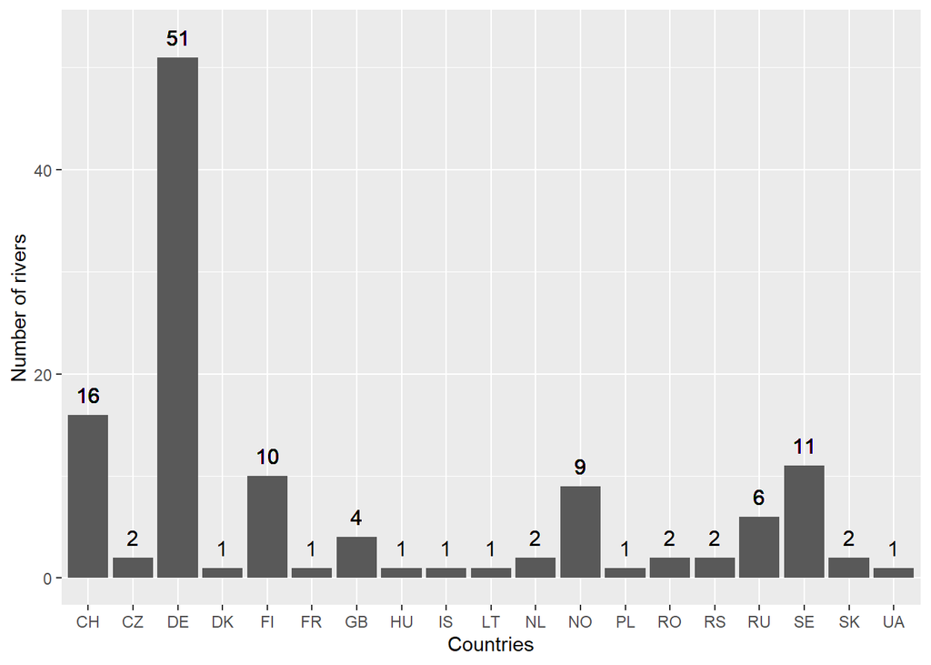

**3. How many stations exist per river?**

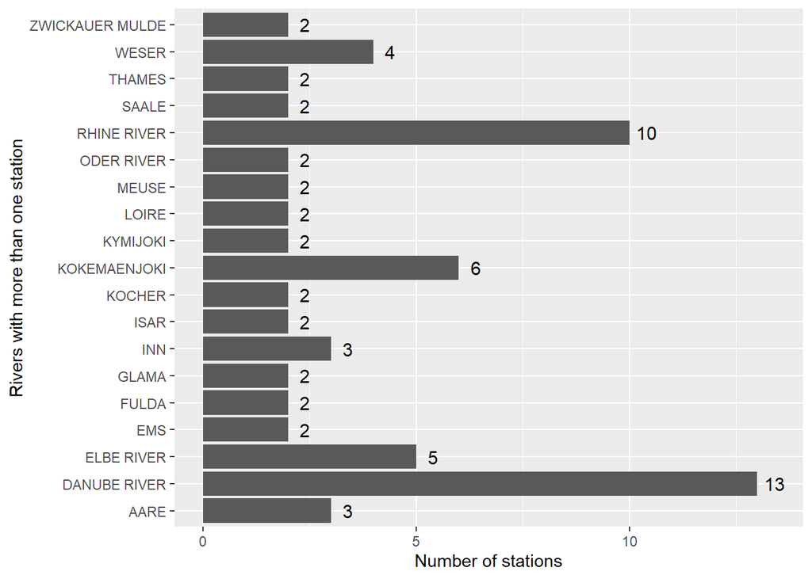

**4. Which is the distribution of stations in space?**

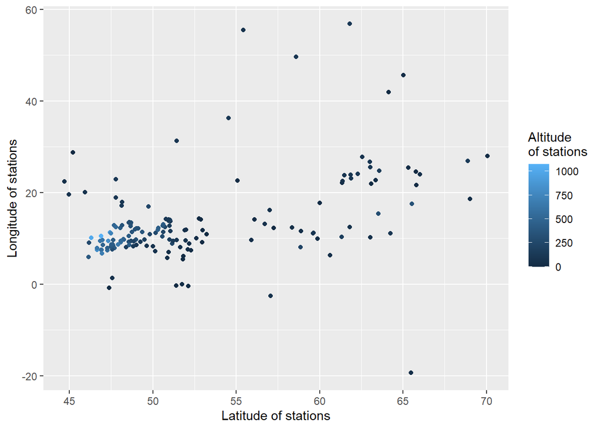

**5. Which is the distribution of record length?**

Here we can see that most of stations lie between 80 and 120 years old.

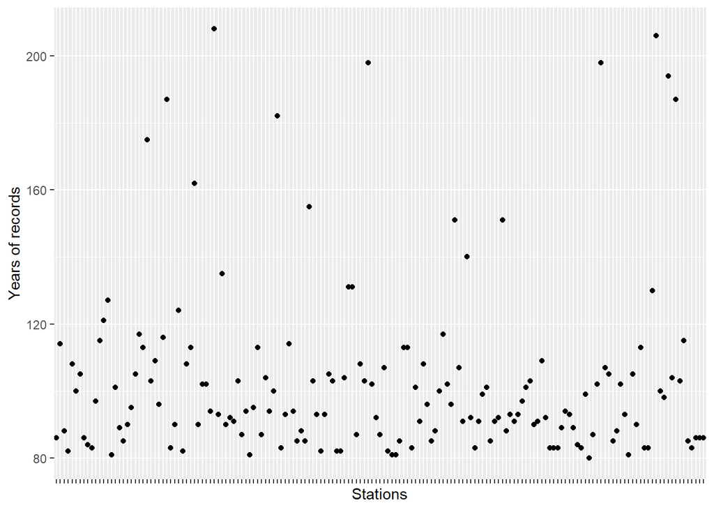

## Annual and seasonal runoff

Using runoff_eu_year.rds we can get some descriptive statistics grouped by LQ(low runoff),MQ(average runoff) and HQ(high runoff).

```
##    Data\ngroups Mean Standard\ndeviation Coefficient\nof variation Maximum
## 1:           LQ  159                 439                        NA    7160
## 2:           MG  337                 812                        NA    9499
## 3:           HQ  711                1685                        NA   20800
##    Minimum
## 1:       0
## 2:       0
## 3:       1
```

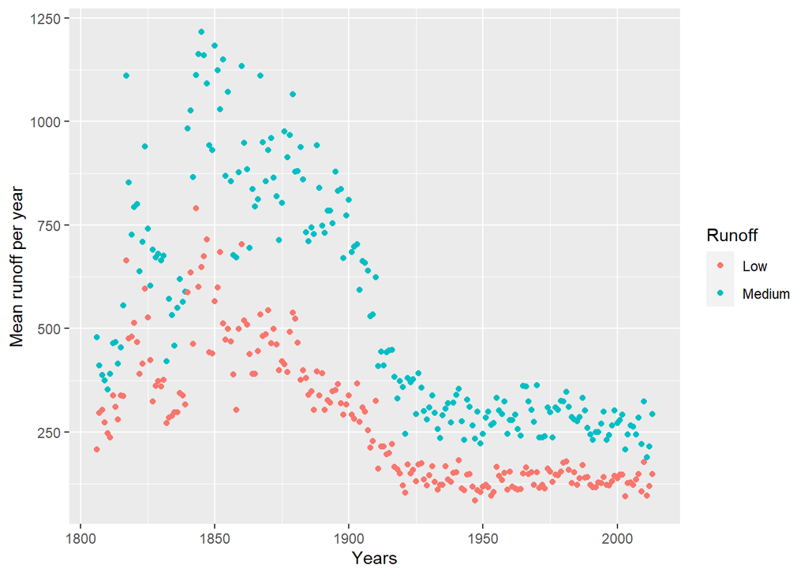

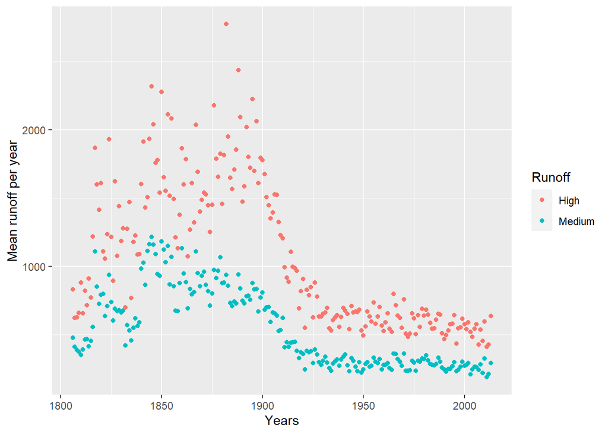

Then I added some categories, such as the station height category and the recording length category.

Using a bit of statistical data we can look at change in the ratios of mean/high and mean/low runoff ratios for before and after 1980 for each station separately and for the categories.

```
##           id                 sname         MH          ML  MH_Before  ML_Before
##   1: 6140400                 DECIN 0.06804348  9.20588235 0.07083079  9.1580047
##   2: 6140700                  name 0.02830189         Inf 0.03119272        Inf
##   3: 6142100            MORAVICANY 0.02821869 -0.01601602 0.07100094 17.5372319
##   4: 6142120                  name 0.06941176 23.98373984 0.09851759 15.9758258
##   5: 6142200            BRATISLAVA 0.19941663  3.53620690 0.19869636  3.5234346
##  ---
## 196: 6970250            UST-PINEGA 0.03372549 -1.03303303 0.01272293 -0.3897114
## 197: 6970500      MALONISOGORSKAYA 0.06571429 -0.62162162 0.06805978 -0.6438087
## 198: 6970705 YAKSHA (YAKSHINSKAYA) 0.07772277 11.21428571 0.09865658 11.7227236
## 199: 6972430                  name 0.55545455  5.31304348 0.54553948  5.2182037
## 200: 6974150           SMALININKAI 0.07138669 -0.48748749 0.07209351 -0.4923143
##        MH_After   ML_After
##   1: 0.06912770  3.8173758
##   2: 0.04551160        Inf
##   3: 0.02095679 -0.0118944
##   4: 0.06870805 23.7405862
##   5: 0.20361819  2.7427775
##  ---
## 196: 0.10718469 -3.0470924
## 197: 0.06697287 -0.5785545
## 198: 0.08439818 10.4894886
## 199: 0.63905020  4.4584898
## 200: 0.15150729 -0.4580100
```

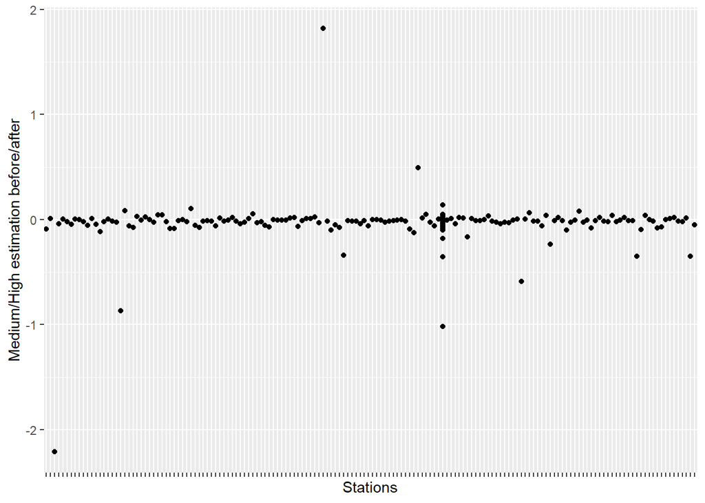

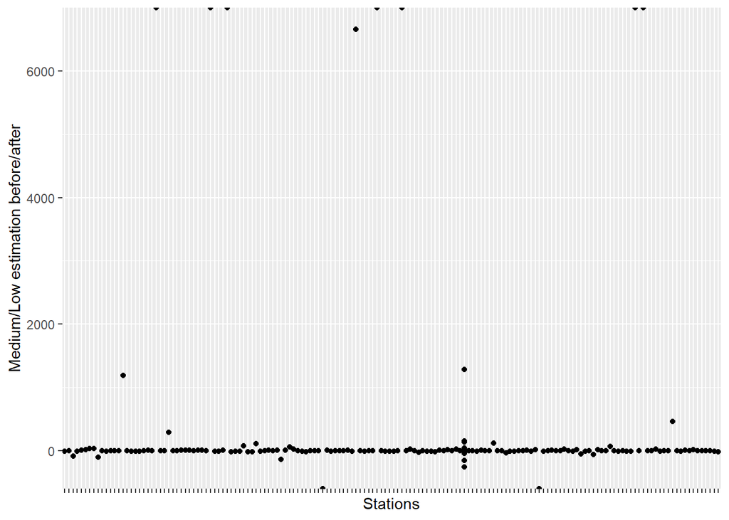

Estimation for the categories:

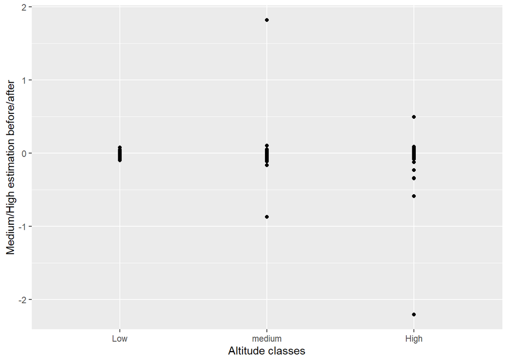

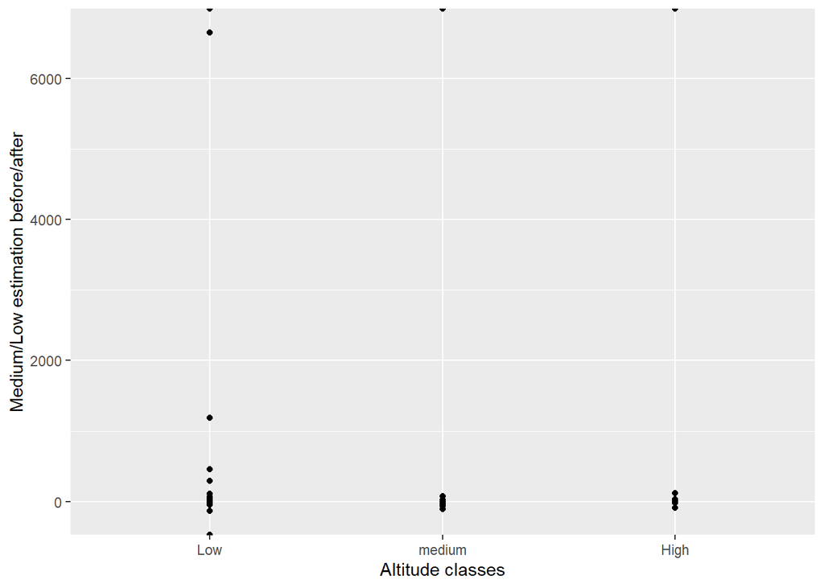

During the course, we have already come to do classification by season, and here is an example of the result:

```
##           id   year_type       value
##   1: 6123100 before 1980  364.520460
##   2: 6140400 before 1980  232.593809
##   3: 6140700 before 1980    2.032758
##   4: 6142100 before 1980   12.548593
##   5: 6142120 before 1980   45.246240
##  ---
## 197: 6970250 before 1980  695.279471
## 198: 6970500 before 1980  786.970324
## 199: 6970705 before 1980  359.744565
## 200: 6972430 before 1980 2915.895031
## 201: 6974150 before 1980  346.175078
```

Finally we display the map:

[interactive chart not shown]

## Five rivers

### Stations for research:

- **MALANGSFOSS** Country: Norway. Why: Isolated at the very north of the Norway. Also, according to data from the network, this area is abundant with waterfalls, which can also have an impact on the flow.
- **MALONISOGORSKAYA** Country: Russia. Why: Partly isolated, but there may be industrial influence. Also, according to data from the network, the river has a mixed, mainly snow-fed supply. Fishing is developed on the river, as well as in the seasons there is raft wood.
- **WITTENBERGE** Country: Germany. Why: Center of Europe, hope we can se here good data for comparison. According to the network data, the river is subject to a strong industrial impact, and several ports are located along the river.
- **GETEBRO** Country: Sweden. Why: Possible influence of tourists/locals. According to the network data, part of the drain passes through protected areas, which can give cleaner comparative results.
- **SATU MARE** Country: Romania. Why: Possible influence of runoff from the mountains. According to the network, the river has its source in the mountains, and also has a predominantly snow / rain supply. Used for logging. the lower course of the river is straightened by artificial channels, river navigation is possible. In the lower reaches of the river water is used for irrigation.

### Runoff seasonality

Now let’s present the flow data for each station for the months before 1980:

- **MALANGSFOSS**The flow pattern shows that the amount of water increases during the summer months. This may be due to the Northern location and the surrounding mountainous landscape. We also see a slight decrease in maximum runoff values after 1980.
- **MALONISOGORSKAYA** A sharp increase in runoff in the spring months is associated with the Northern position of the station and is explained by the melting of ice. However, there are no major changes in runoff after 1980.
- **WITTENBERGE** The average values remain the same throughout the station’s observation, but after 1980, some maximum flow values can be observed increasing in the spring/summer months.
- **GETEBRO** Here we don’t see much change in the runoff since 1980. A slight increase in runoff in the spring months, which may be due to the near-mountainous landscape.
- **SATU MARE** The natural increase in runoff in the spring months is supported by the mountain landscape. However, according to our data, we see a decrease in the total flow of the river after 1980.

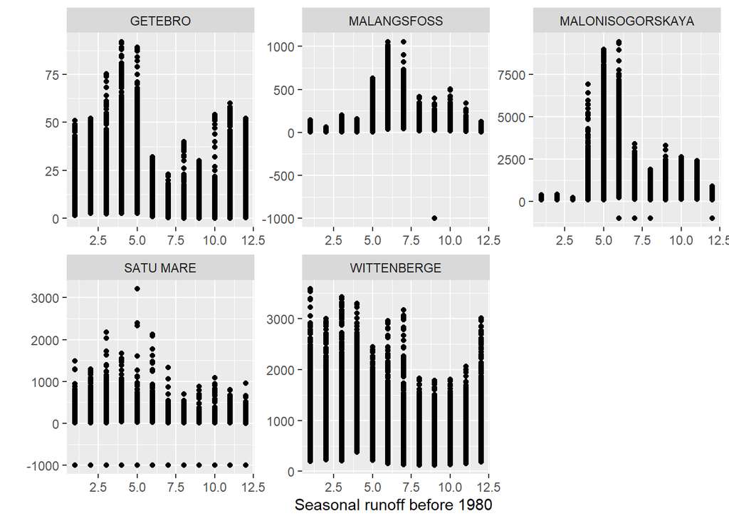

And after 1980.

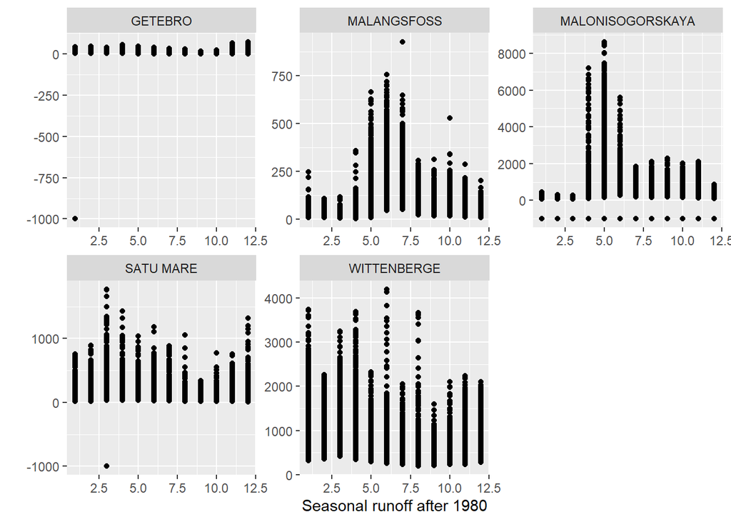

### Correlation matrix

The correlation data before and after 1980 are the same. We can also see: - GETEBRO and WITTENBERGE have a weak direct connection, which can be explained by completely different anthropogenic conditions in the area. - MALANGSFOSS and GETEBRO have weak feedback, which is strange, since both of these zones are not affected by anthropogenic influence, but can be explained by the abundant waterfalls in the MALANGSFOSS area.

Correlation matrix for data after year 1980:

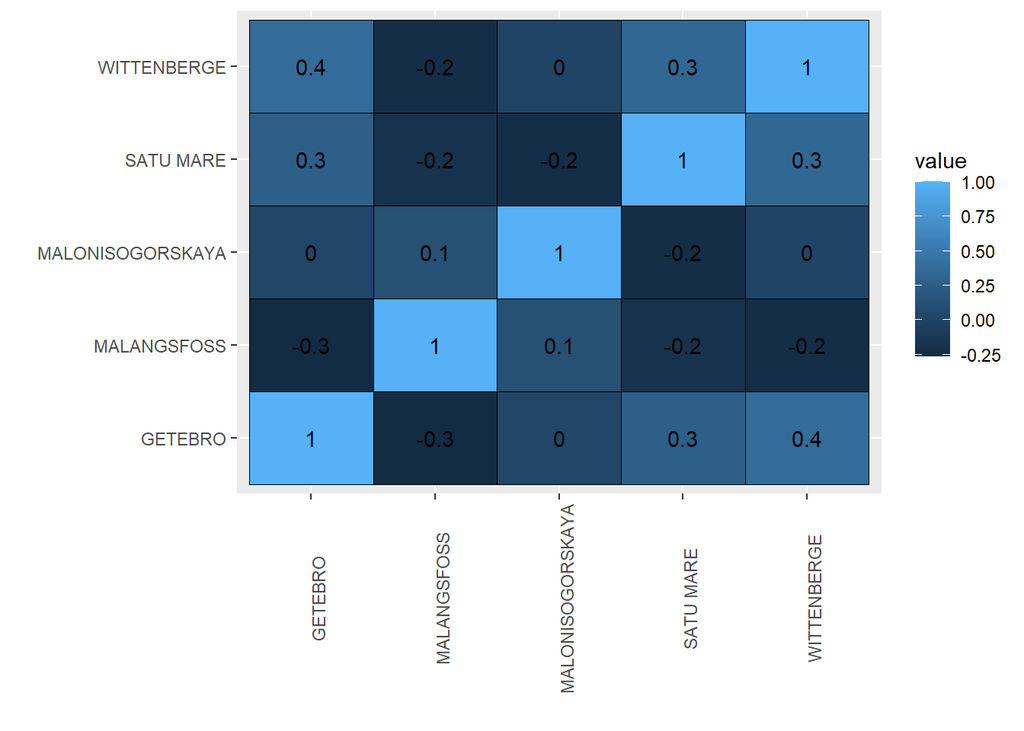

Correlation matrix for data before year 1980:

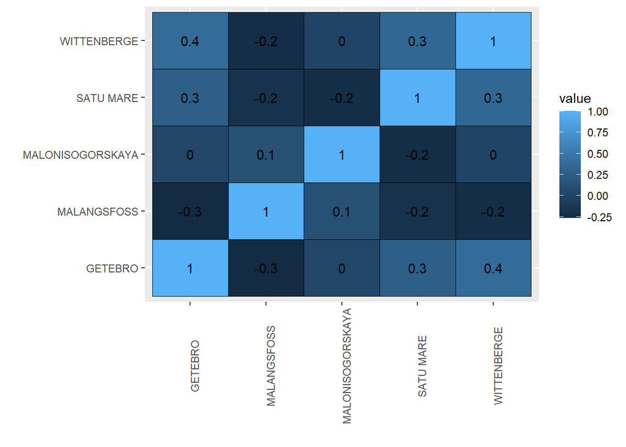

### Regression slopes in winter/summer runoff per station

- **MALANGSFOSS** We can observe a drop in the overall level since 1940, but the data after 1980 do not give clear answers, because they have a wave-like shape.
- **MALONISOGORSKAYA** We see an overall increase in runoff during the summer months throughout the period, with the exception of 1990-2000, where we can see a drop.
- **WITTENBERGE** We can see a clear drop between 1980 and 2005, which may be closely related to human impact.
- **GETEBRO** We can observe a slight stabilization of the runoff after 1980.
- **SATU MARE** We can observe a drop in the total summer runoff after 1980 until 1990, after which the situation stabilizes.

Summer runoff:

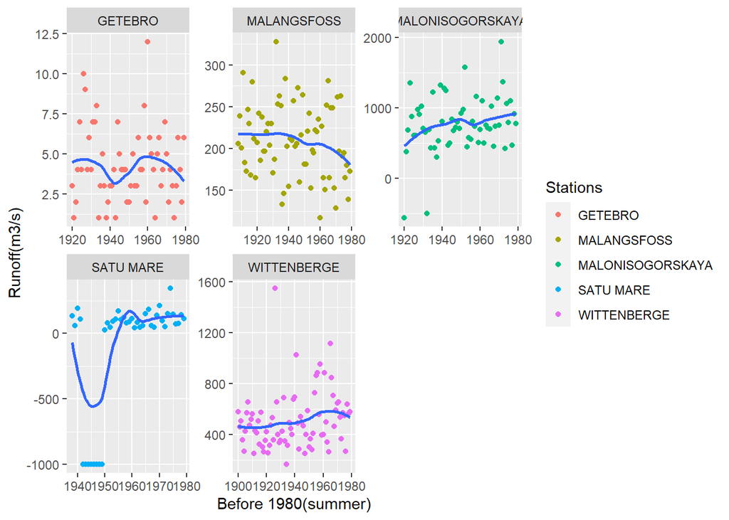

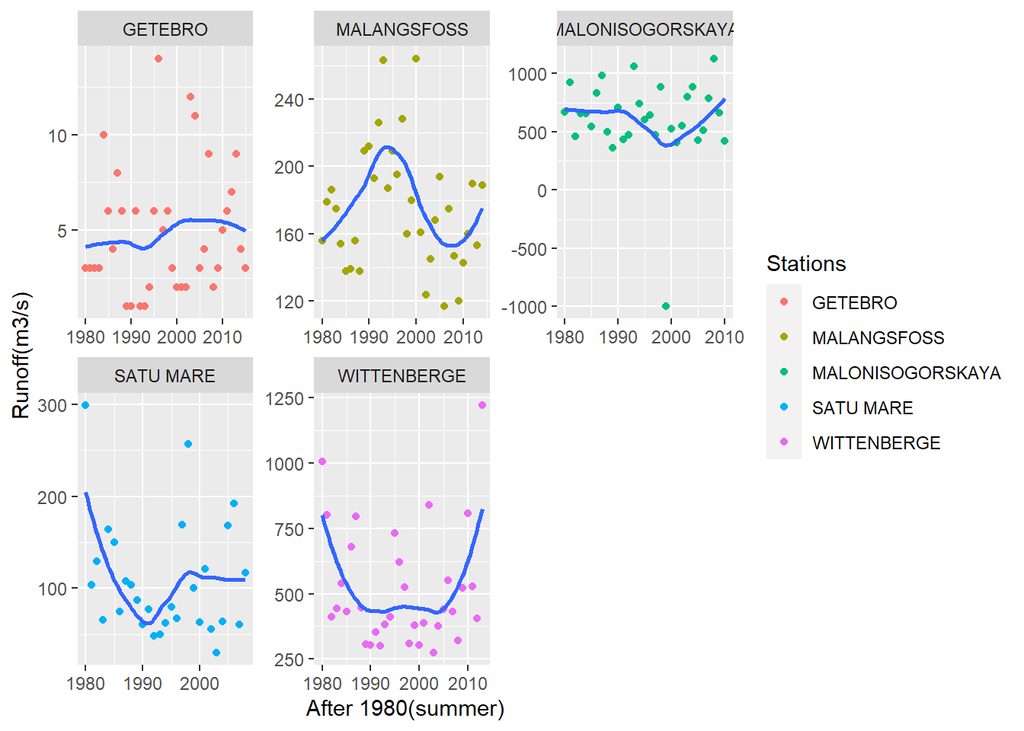

Winter runoff:

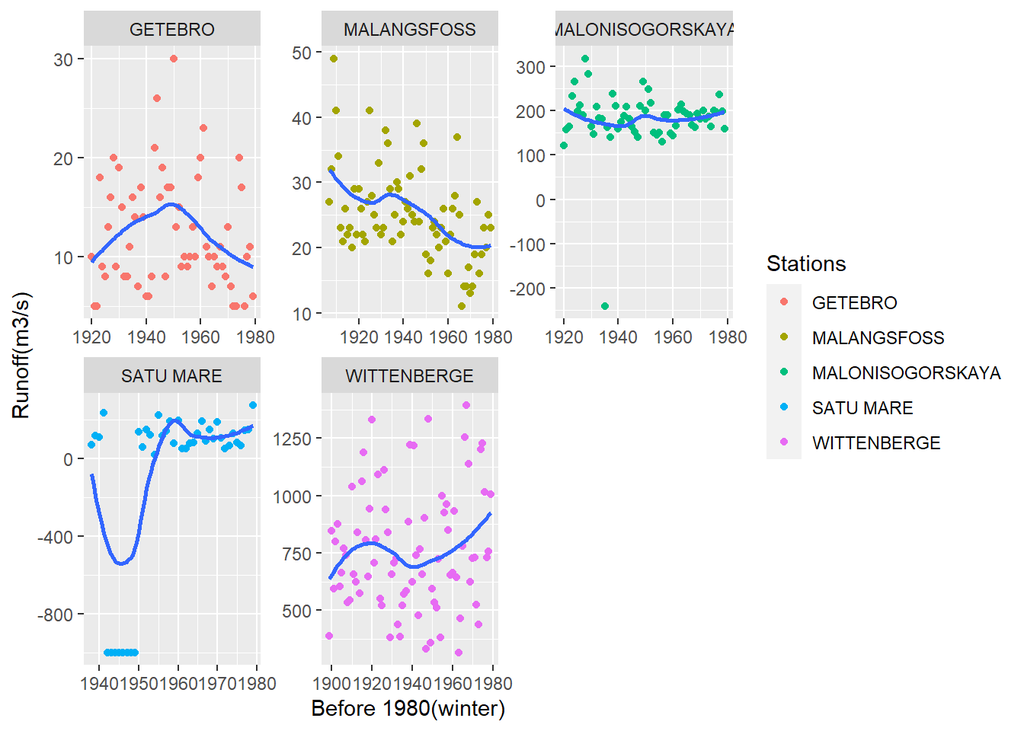

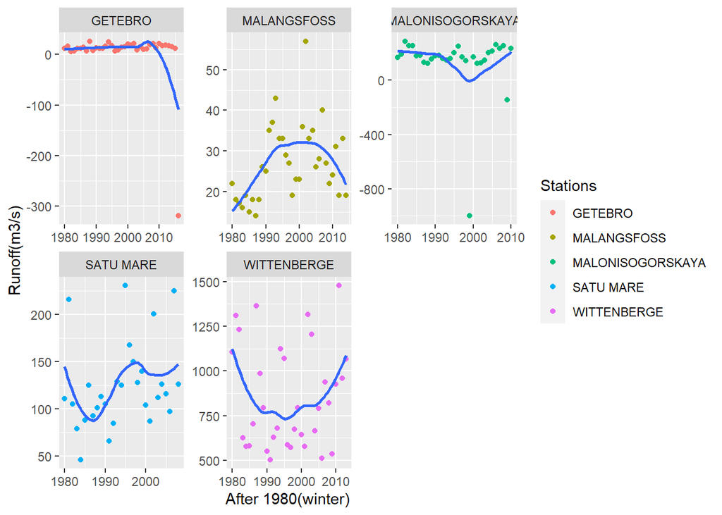